# Dada2_Ringel2015

# Import library

```r
library(dada2)
packageVersion("dada2") # check dada2 version
```

```
## [1] '1.21.0'
```

```r
library(Biostrings)
library(ShortRead)
library(seqTools) # per base sequence content
library(phyloseq)
library(ggplot2)
library(data.table)
library(plyr)
library(dplyr)
library(qckitfastq) # per base sequence content
library(stringr)
```

## QUALITY CHECK

First, we import the fastq files containing the raw reads. The samples were downloaded from the ENA database with the accession number SRP066323.

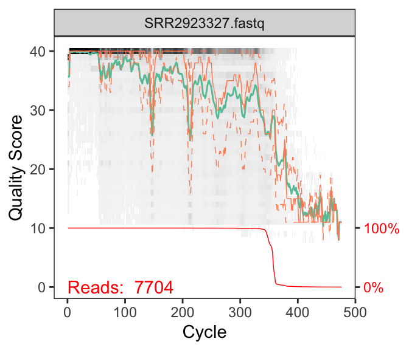

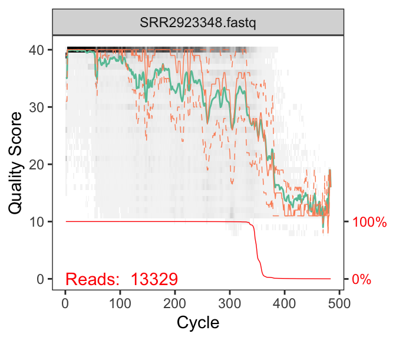

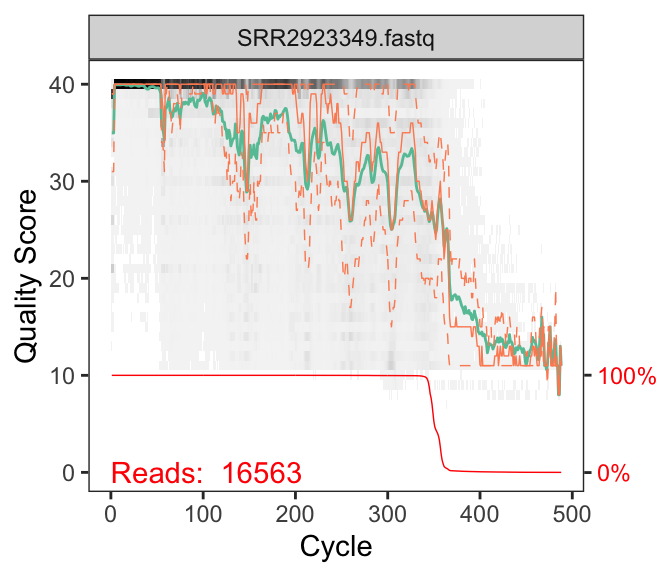

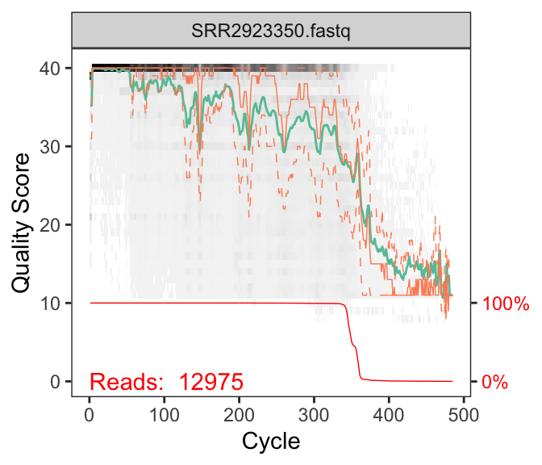

```r
# Save the path to the directory containing the fastq zipped files
path <- "~/Projects/IBS_Meta-analysis_16S/data/analysis-individual/Ringel-2015"
# list.files(path) # check we are in the right directory

# fastq filenames have format: SAMPLENAME.fastq
# Saves the whole directory path to each file name
FNs <- sort(list.files(file.path(path, "original"), pattern=".fastq", full.names = TRUE))
show(FNs[1:5])

# Extract sample names, assuming filenames have format: SAMPLENAME.fastq
sample.names <- sapply(strsplit(basename(FNs), "_"), `[`, 1)
show(sample.names[1:5]) # saves only the file name (without the path)

# Look at quality of all files
for (i in 1:4){ # 1:length(FNs)
  show(plotQualityProfile(FNs[i]))
}
```

```r
# Look at number of reads per sample
# raw_stats <- data.frame('sample' = sample.names,
#                         'reads' = fastqq(FNs)@nReads)
# min(raw_stats$reads)
# max(raw_stats$reads)
# mean(raw_stats$reads)
```

We will have a quick peak at the per base sequence content of the reads in some samples, to make sure there is no anomaly (i.e. all reads having the same sequence).

```r
# Look at per base sequence content
fseq <- seqTools::fastqq(FNs[10])
```

```
## [fastqq] File ( 1/1) '/Users/scarcy/Projects/IBS_Meta-analysis_16S/data/analysis-individual/Ringel-2015/original/SRR2923356.fastq'   done.
```

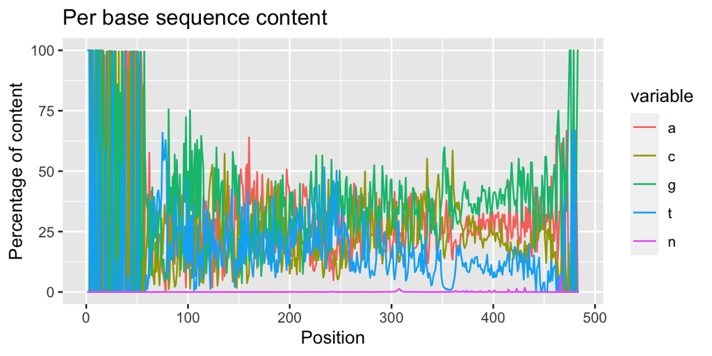

```r
rc <- read_content(fseq)
plot_read_content(rc) + labs(title = "Per base sequence content")
```

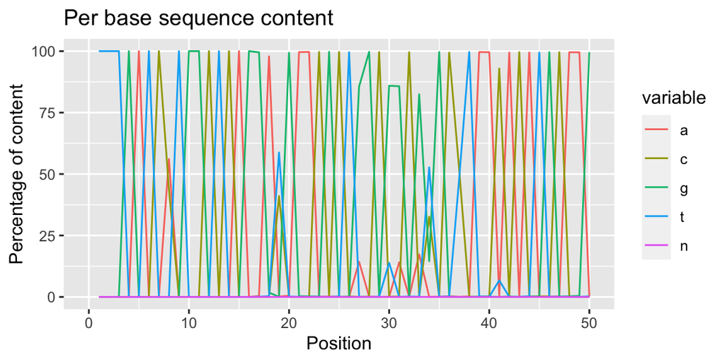

```r
plot_read_content(rc) + xlim(0,50) + labs(title = "Per base sequence content")
```

## LOOK FOR PRIMERS

Now, we will look whether the reads still contain the primers.

```r
# V1-V2
FWD <- "TTTGATCMTGGCTCAG"  # 8F primer sequence (in reality, it's 5'-12-27-3')
REV <- "CTGCTGCCTYCCGTA" # 357R primer sequence (in reality, it's 5'-357-543-3')

# Function that, from the primer sequence, will return all combinations possible (complement, reverse complement, ...)
allOrients <- function(primer) {
    # Create all orientations of the input sequence
    require(Biostrings)
    dna <- DNAString(primer)  # The Biostrings works w/ DNAString objects rather than character vectors
    orients <- c(Forward = dna, Complement = complement(dna), Reverse = reverse(dna),
        RevComp = reverseComplement(dna))
    return(sapply(orients, toString))
}
FWD.orients <- allOrients(FWD) # get all combinations for the 8F primer sequence
REV.orients <- allOrients(REV) # get all combinations for the 357R primer sequence
FWD.orients # sanity check
```

```
##            Forward         Complement            Reverse            RevComp
## "TTTGATCMTGGCTCAG" "AAACTAGKACCGAGTC" "GACTCGGTMCTAGTTT" "CTGAGCCAKGATCAAA"
```

```r
REV.orients
```

```
##           Forward        Complement           Reverse           RevComp
## "CTGCTGCCTYCCGTA" "GACGACGGARGGCAT" "ATGCCYTCCGTCGTC" "TACGGRAGGCAGCAG"
```

```r
# Function that counts number of reads in which a sequence is found
primerHits <- function(primer, fn) {
    nhits <- vcountPattern(primer, sread(readFastq(fn)), fixed = FALSE, max.mismatch = 2)
    return(sum(nhits > 0))
}

# Get a table to know how many times the 8F and 357R primers are found in the reads of each sample
for (i in 1:5){
  cat("SAMPLE", sample.names[i], "with total number of", raw_stats[i,'reads'], "reads\n\n")
  x <- rbind(ForwardPrimer = sapply(FWD.orients, primerHits, fn = FNs[[i]]),
             ReversePrimer = sapply(REV.orients, primerHits, fn = FNs[[i]]))
  print(x)
  cat("\n____________________________________________\n\n")
}
```

```
## SAMPLE SRR2923327.fastq with total number of 7704 reads
##
##               Forward Complement Reverse RevComp
## ForwardPrimer    7704          0       0       0
## ReversePrimer       0          1       0    3909
##
## ____________________________________________
##
## SAMPLE SRR2923348.fastq with total number of 13329 reads
##
##               Forward Complement Reverse RevComp
## ForwardPrimer   13329          0       0       1
## ReversePrimer       0          1       0    6990
##
## ____________________________________________
##
## SAMPLE SRR2923349.fastq with total number of 16563 reads
##
##               Forward Complement Reverse RevComp
## ForwardPrimer   16563          0       0       0
## ReversePrimer       0          1       0    8493
##
## ____________________________________________
##
## SAMPLE SRR2923350.fastq with total number of 12975 reads
##
##               Forward Complement Reverse RevComp
## ForwardPrimer   12975          0       0       1
## ReversePrimer       0          1       0    7982
##
## ____________________________________________
##
## SAMPLE SRR2923351.fastq with total number of 10889 reads
##
##               Forward Complement Reverse RevComp
## ForwardPrimer   10889          0       0       0
## ReversePrimer       0          2       0    6048
##
## ____________________________________________
```

## FILTER AND TRIM

### 1. Primer removal

The reads indeed contain the forward primer (and half of them the reverse primer). We will keep only reads containing the primers, and then trim the primers!

```r
# KEEP READS WITH PRIMER AND REMOVE PRIMER+BARCODE
# Place filtered files in a filtered/ subdirectory
filt1_samples <- file.path(path, "filtered1", paste0(sample.names, "_filt.fastq.gz"))
# Assign names for the filtered fastq.gz files
names(filt1_samples) <- sample.names

# Filter first to take out primer
out1 <- removePrimers(fn = FNs, fout = filt1_samples,
                      primer.fwd = FWD.orients['Forward'], # forward primer is found at the beginning of the reads
                      primer.rev = REV.orients['RevComp'], # revcomp of the REV primer at the end of the reads
                      trim.fwd = TRUE,
                      trim.rev = TRUE,
                      orient = FALSE, # keep the reads in their original orientation
                      compress = TRUE, verbose = TRUE)
```

```r
# Primer removal
out1[1:4,]
```

```
##                  reads.in reads.out
## SRR2923327.fastq     7704      3909
## SRR2923348.fastq    13329      6990
## SRR2923349.fastq    16563      8493
## SRR2923350.fastq    12975      7982
```

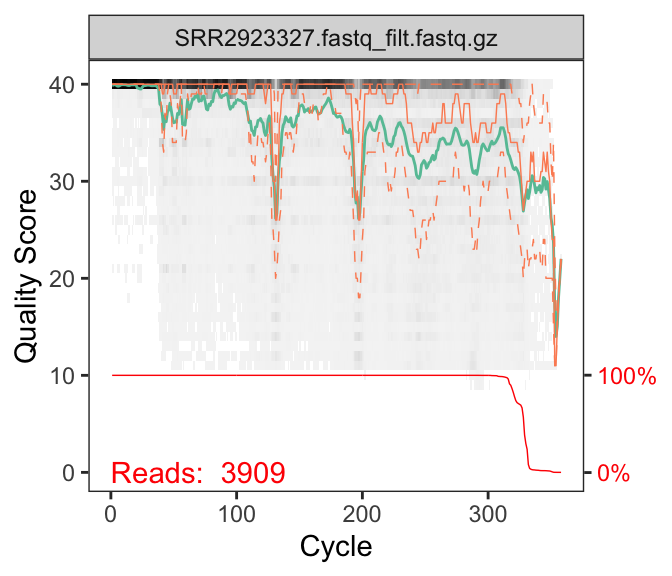

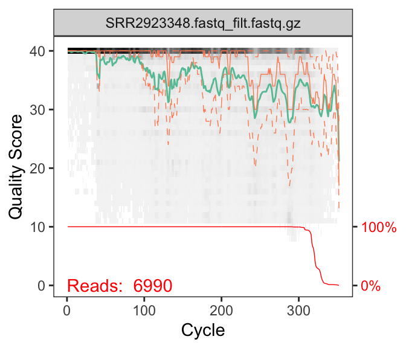

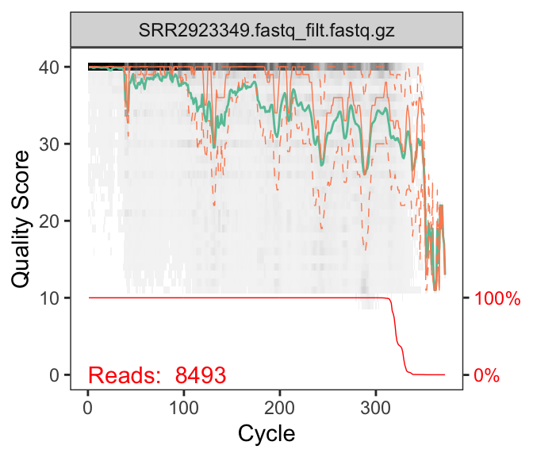

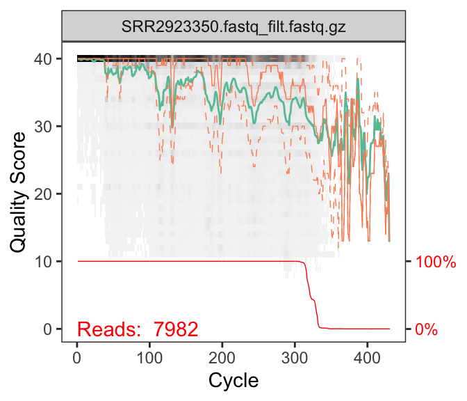

```r
# Quality profile after primer removal
for (i in 1:4){
  show(plotQualityProfile(filt1_samples[i]))
}
```

### 2. Quality filtering

Then, we perform a quality filtering of the reads.

```r
# Place filtered files in a filtered/ subdirectory
filt2_samples <- file.path(path, "filtered2", paste0(sample.names, "_filt.fastq.gz"))
# Assign names for the filtered fastq.gz files
names(filt2_samples) <- sample.names

# Filter
out2 <- filterAndTrim(fwd = filt1_samples, filt = filt2_samples,
                     maxEE=3, # reads with more than 3 expected errors (sum(10e(-Q/10))) are discarded
                     truncQ=10, # Truncate reads at the first instance of a quality score less than or equal to truncQ.
                     minLen = 150, # Discard reads shorter than 150 bp. This is done after trimming and truncation.
                     compress=TRUE,
                     multithread=TRUE,
                     verbose=TRUE)
```

Let’s look at the output filtered fastq files as sanity check.

```r
out2[1:4,]
```

```
##                                reads.in reads.out
## SRR2923327.fastq_filt.fastq.gz     3909      3850
## SRR2923348.fastq_filt.fastq.gz     6990      6874
## SRR2923349.fastq_filt.fastq.gz     8493      8333
## SRR2923350.fastq_filt.fastq.gz     7982      7863
```

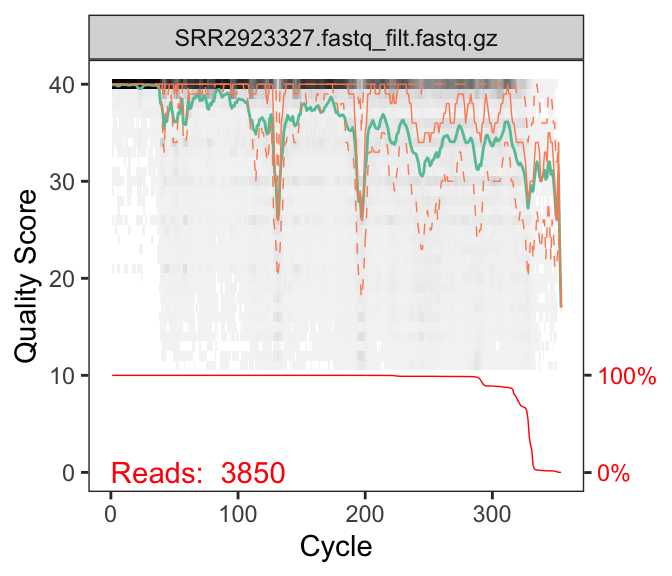

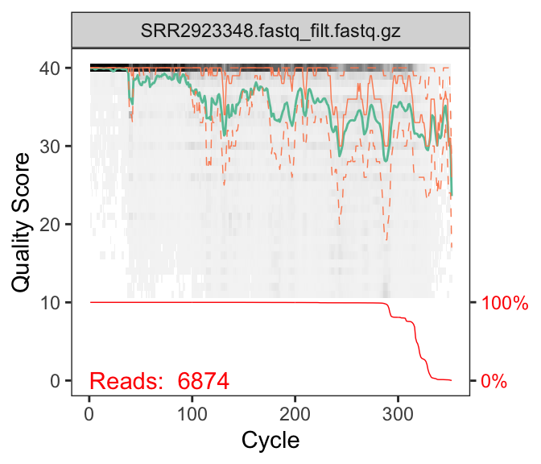

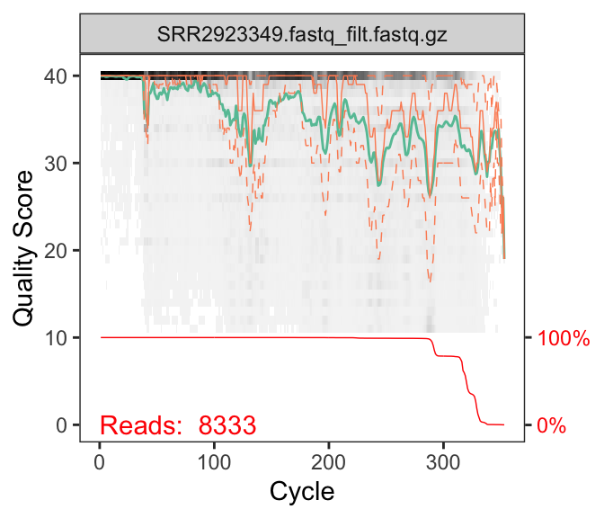

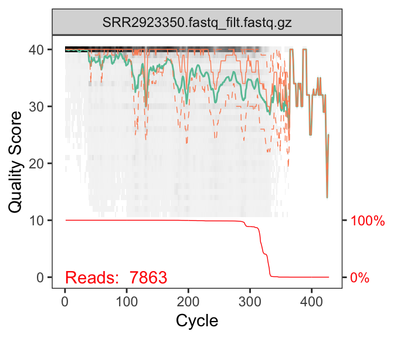

```r
# Look at quality profile of filtered files
for (i in 1:4){
  show(plotQualityProfile(filt2_samples[i]))
}
```

## LEARN ERROR RATES

Now we will build the parametric error model, to be able to infer amplicon sequence variants (ASVs) later on.

```r
err <- learnErrors(filt2_samples, multithread=TRUE, randomize=TRUE, verbose = 1)
```

The error rates for each possible transition (A→C, A→G, …) are shown. Points are the observed error rates for each consensus quality score. The black line shows the estimated error rates after convergence of the machine-learning algorithm. The red line shows the error rates expected under the nominal definition of the Q-score. Here the estimated error rates (black line) are a good fit to the observed rates (points), and the error rates drop with increased quality as expected.

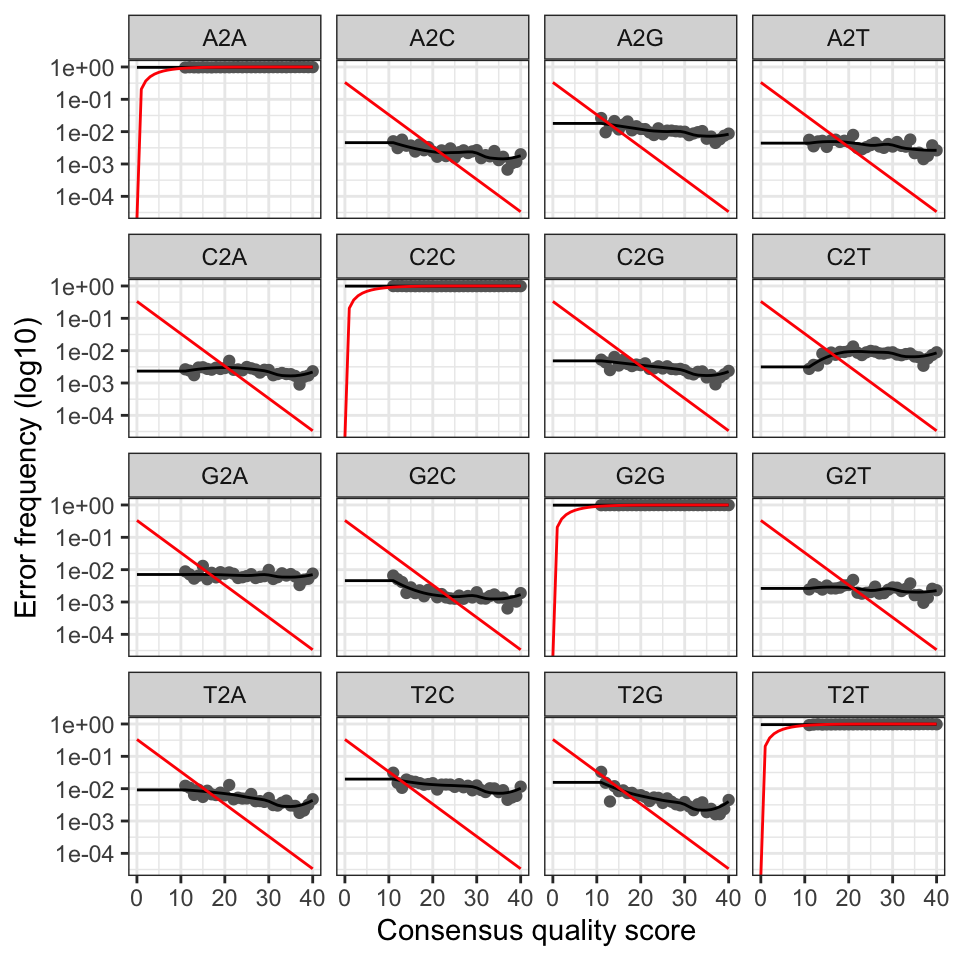

```r
plotErrors(err, nominalQ = TRUE)
```

## CONSTRUCT SEQUENCE TABLE

### 1. Infer sample composition

The *dada()* algorithm infers sequence variants based on estimated errors (previous step). Firstly, we de-replicate the reads in each sample, to reduce the computation time. De-replication is a common step in almost all modern ASV inference (or OTU picking) pipelines, but a unique feature of derepFastq is that it maintains a summary of the quality information for each dereplicated sequence in $quals.

```r
# Prepare empty vector for the infered sequences
seq_infered <- vector("list", length(sample.names))
names(seq_infered) <- sample.names

# Iterate through the 76 samples
for(sampl in sample.names) {
  cat("Processing:", sampl, "\n")
  derep <- derepFastq(filt2_samples[[sampl]]) # dereplicate the reads in the sample
  seq_infered[[sampl]] <- dada(derep, err=err, multithread=TRUE, # default parameters
                               HOMOPOLYMER_GAP_PENALTY=-1, BAND_SIZE=32) # parameters for 454 sequencing recommended
}
```

```r
# Inspect the infered sequence variants from sample 1:5
for (i in 1:5){
  print(seq_infered[[i]])
  print("________________")
}
```

```
## dada-class: object describing DADA2 denoising results
## 62 sequence variants were inferred from 2767 input unique sequences.
## Key parameters: OMEGA_A = 1e-40, OMEGA_C = 1e-40, BAND_SIZE = 32
## [1] "________________"
## dada-class: object describing DADA2 denoising results
## 61 sequence variants were inferred from 4666 input unique sequences.
## Key parameters: OMEGA_A = 1e-40, OMEGA_C = 1e-40, BAND_SIZE = 32
## [1] "________________"
## dada-class: object describing DADA2 denoising results
## 62 sequence variants were inferred from 5623 input unique sequences.
## Key parameters: OMEGA_A = 1e-40, OMEGA_C = 1e-40, BAND_SIZE = 32
## [1] "________________"
## dada-class: object describing DADA2 denoising results
## 120 sequence variants were inferred from 5663 input unique sequences.
## Key parameters: OMEGA_A = 1e-40, OMEGA_C = 1e-40, BAND_SIZE = 32
## [1] "________________"
## dada-class: object describing DADA2 denoising results
## 64 sequence variants were inferred from 4214 input unique sequences.
## Key parameters: OMEGA_A = 1e-40, OMEGA_C = 1e-40, BAND_SIZE = 32
## [1] "________________"
```

### 2. Construct ASV table

We can now construct an amplicon sequence variant table (ASV) table, a higher-resolution version of the OTU table produced by traditional methods.

```r
# Make sequence table from the infered sequence variants
seqtable <- makeSequenceTable(seq_infered)

# We should have 76 samples (76 rows)
dim(seqtable)
```

```
## [1]   76 3455
```

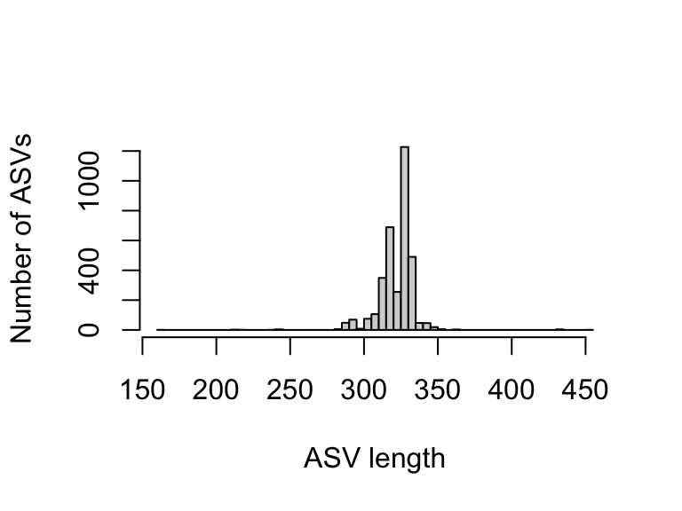

```r
# Inspect distribution of sequence lengths
hist(nchar(getSequences(seqtable)), breaks = 100, xlab = "ASV length", ylab = "Number of ASVs", main="")
```

```r
# Sequences should be between 8F - 357R, so around ~310bp (removing the primers lengths).
# Remove any sequence variant outside 250-400bp
seqtable.new <- seqtable[,nchar(colnames(seqtable)) %in% 260:360]
dim(seqtable.new)
```

```
## [1]   76 3438
```

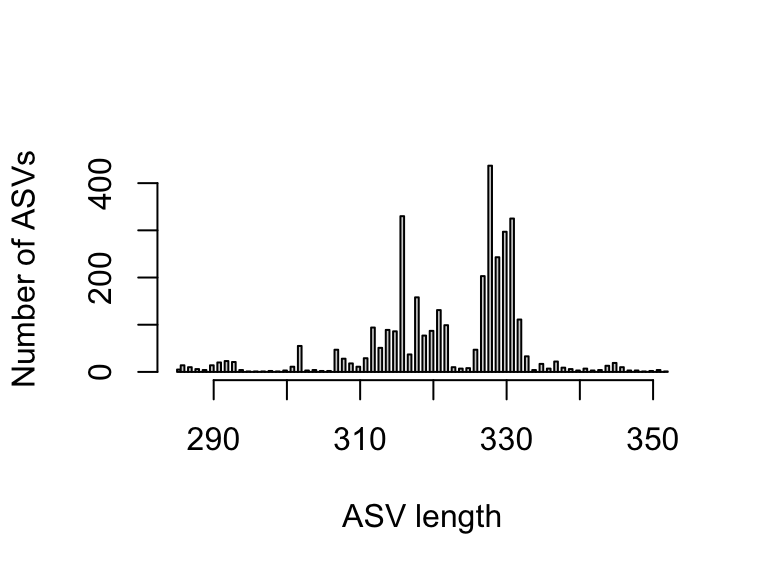

```r
hist(nchar(getSequences(seqtable.new)), breaks = 100, xlab = "ASV length", ylab = "Number of ASVs", main="")
```

### 3. Remove chimeras

The core dada method corrects substitution and indel errors, but chimeras remain. Fortunately, the accuracy of sequence variants after denoising makes identifying chimeric ASVs simpler than when dealing with fuzzy OTUs. Chimeric sequences are identified if they can be exactly reconstructed by combining a left-segment and a right-segment from two more abundant “parent” sequences.

```r
seqtable.nochim <- removeBimeraDenovo(seqtable.new, method="consensus", multithread=TRUE, verbose=TRUE)

# Check how many sequence variants we have after removing chimeras
dim(seqtable.nochim)
```

```
## [1]   76 3264
```

```r
# Check how many reads we have after removing chimeras (we should keep the vast majority of the reads, like > 80%)
sum(seqtable.nochim)/sum(seqtable.new)
```

```
## [1] 0.9817262
```

## LOOK AT READS COUNT THROUGH PIPELINE

Sanity check before assigning taxonomy.

```r
# Function that counts nb of reads
getN <- function(x) sum(getUniques(x))

# Table that will count number of reads for each process of interest (input reads, filtered reads, denoised reads, non chimera reads)
track <- cbind(out1,
               out2[,2],
               sapply(seq_infered, getN),
               rowSums(seqtable.nochim),
               lapply(rowSums(seqtable.nochim)*100/out1[,1], as.integer))

# Assign column and row names
colnames(track) <- c("input", "primer-filt", "quality-filt", "denoised", "nonchim", "%input->output")
rownames(track) <- sample.names

# Show final table: for each row/sample, we have shown the initial number of reads, filtered reads, denoised reads, and non chimera reads
track
```

```
##                  input primer-filt quality-filt denoised nonchim %input->output
## SRR2923327.fastq 7704  3909        3850         3534     3444    44
## SRR2923348.fastq 13329 6990        6874         6322     6322    47
## SRR2923349.fastq 16563 8493        8333         7958     7937    47
## SRR2923350.fastq 12975 7982        7863         7152     7092    54
## SRR2923351.fastq 10889 6048        5952         5585     5165    47
## SRR2923352.fastq 118   69          69           18       18      15
## SRR2923353.fastq 13278 7841        7698         7384     7130    53
## SRR2923354.fastq 12448 8281        8158         7789     7775    62
## SRR2923355.fastq 9190  4756        4685         4048     4048    44
## SRR2923356.fastq 20687 11682       11522        10825    10814   52
## SRR2923357.fastq 11925 6154        6014         5409     5331    44
## SRR2923358.fastq 20238 12365       12202        11396    11087   54
## SRR2923359.fastq 9335  4811        4740         4043     4015    43
## SRR2923360.fastq 7693  3867        3812         3239     3239    42
## SRR2923361.fastq 5832  2888        2852         2319     2319    39
## SRR2923362.fastq 7750  4982        4922         4372     4372    56
## SRR2923363.fastq 18162 10862       10702        10250    9903    54
## SRR2923364.fastq 14718 7540        7421         6708     6528    44
## SRR2923365.fastq 13092 6509        6261         5929     5929    45
## SRR2923366.fastq 15645 10134       9983         9344     9280    59
## SRR2923368.fastq 7600  3871        3778         3570     3524    46
## SRR2923369.fastq 10568 5750        5672         5240     5161    48
## SRR2923371.fastq 10260 5120        5029         4640     4640    45
## SRR2923373.fastq 16278 10307       10112        9782     9688    59
## SRR2923375.fastq 15179 8201        8054         7599     7485    49
## SRR2923376.fastq 5610  3004        2970         2505     2474    44
## SRR2923378.fastq 21563 10602       10483        10013    9993    46
## SRR2923380.fastq 11954 7594        7489         7126     7126    59
## SRR2923382.fastq 18135 9332        9169         8875     8875    48
## SRR2923383.fastq 9926  4803        4686         4297     4297    43
## SRR2923385.fastq 11472 5450        5370         4986     4986    43
## SRR2923387.fastq 12327 8031        7899         7311     7114    57
## SRR2923390.fastq 17059 9309        9169         8536     8409    49
## SRR2923391.fastq 15714 8212        8075         7538     7298    46
## SRR2923393.fastq 6118  4411        4370         4180     3747    61
## SRR2923395.fastq 19012 13115       12947        12142    11798   62
## SRR2923397.fastq 9642  5259        5164         4709     4691    48
## SRR2923398.fastq 16213 8059        7938         7481     7260    44
## SRR2923399.fastq 13295 8805        8588         8051     7899    59
```

[output cut: 22 more lines]

```
## SRR2923791.fastq 6125  3424        3376         2794     2785    45
## SRR2923792.fastq 13683 8854        8696         8257     8234    60
## SRR2923794.fastq 10636 6794        6681         6431     6421    60
## SRR2923796.fastq 16060 8364        8207         7786     7682    47
## SRR2923797.fastq 13834 7201        7102         6200     6192    44
## SRR2923799.fastq 14066 9077        8956         8180     8124    57
## SRR2923800.fastq 14390 9086        8947         8129     7653    53
## SRR2923802.fastq 8344  4368        4276         3869     3869    46
## SRR2923803.fastq 15499 8238        8111         7650     7483    48
## SRR2923805.fastq 10391 6986        6874         6046     5948    57
## SRR2923806.fastq 12684 8630        8535         7604     7544    59
## SRR2923808.fastq 17026 9070        8912         8589     8446    49
## SRR2923809.fastq 11640 6136        6031         5470     5400    46
## SRR2923811.fastq 15192 11211       11093        10695    10022   65
## SRR2923813.fastq 19147 12716       12503        11571    11237   58
```

## ASSIGN TAXONOMY

Extensions: The dada2 package also implements a method to make species level assignments based on exact matching between ASVs and sequenced reference strains. Recent analysis suggests that exact matching (or 100% identity) is the only appropriate way to assign species to 16S gene fragments. Currently, species-assignment training fastas are available for the Silva and RDP 16S databases. To follow the optional species addition step, download the silva_species_assignment_v132.fa.gz file, and place it in the directory with the fastq files.

```r
# Assign taxonomy (with silva v138)
taxa <- assignTaxonomy(seqtable.nochim, "~/Projects/IBS_Meta-analysis_16S/data/silva_nr_v138_train_set.fa.gz",
                       tryRC = TRUE, # try reverse complement of the sequences
                       multithread=TRUE, verbose = TRUE)

# Add species assignment
taxa <- addSpecies(taxa, "~/Projects/IBS_Meta-analysis_16S/data/silva_species_assignment_v138.fa.gz")
```

```r
# Check how the taxonomy table looks like
taxa.print <- taxa
rownames(taxa.print) <- NULL # Removing sequence rownames for display only
head(taxa.print)
```

```
##      Kingdom    Phylum         Class         Order
## [1,] "Bacteria" "Bacteroidota" "Bacteroidia" "Bacteroidales"
## [2,] "Bacteria" "Firmicutes"   "Clostridia"  "Lachnospirales"
## [3,] "Bacteria" "Firmicutes"   "Clostridia"  "Lachnospirales"
## [4,] "Bacteria" "Bacteroidota" "Bacteroidia" "Bacteroidales"
## [5,] "Bacteria" "Firmicutes"   "Clostridia"  "Oscillospirales"
## [6,] "Bacteria" "Firmicutes"   "Clostridia"  "Lachnospirales"
##      Family            Genus             Species
## [1,] "Bacteroidaceae"  "Bacteroides"     "vulgatus"
## [2,] "Lachnospiraceae" "Anaerostipes"    "hadrus"
## [3,] "Lachnospiraceae" "Agathobacter"    NA
## [4,] "Bacteroidaceae"  "Bacteroides"     "dorei"
## [5,] "Ruminococcaceae" "Subdoligranulum" NA
## [6,] "Lachnospiraceae" "Agathobacter"    NA
```

```r
table(taxa.print[,1]) # Show the different kingdoms (should be only bacteria)
```

```
##
## Bacteria
##     3264
```

```r
table(taxa.print[,2]) # Show the different phyla
```

```
##
##  Actinobacteriota      Bacteroidota  Campilobacterota     Cyanobacteria
##               114               364                 1                 3
##  Desulfobacterota        Firmicutes    Fusobacteriota   Patescibacteria
##                 8              2687                 1                 1
##    Proteobacteria      Synergistota Verrucomicrobiota             WPS-2
##                71                 3                 6                 3
```

```r
table(is.na(taxa.print[,2])) # is there any unassigned phyla?
```

```
##
## FALSE  TRUE
##  3262     2
```

## LAST PREPROCESSING

We will remove any sample with less than 500 reads from further analysis, and also any ASVs with unassigned phyla.

### 1. Create phyloseq object

The preprocessing will be easier to do with ASV, taxonomic and metadata tables combined in a phyloseq object.

```r
#_________________________
# Import metadata
metadata_table <- read.table("~/Projects/IBS_Meta-analysis_16S/data/analysis-individual/Ringel-2015/RingelSraRunTable.txt", header = TRUE, sep = ",")
colnames(metadata_table)

# Keep relevant covariates
sampledf <- data.frame(metadata_table[,"Run"])
rownames(sampledf) <- metadata_table$Run
colnames(sampledf) <- "Run"

sampledf$sample_type <- "stool"
sampledf$author <- "Ringel"
sampledf$sequencing_tech <- "454 pyrosequencing"
sampledf$variable_region <- "V1-V2"

# Remove .fastq extension in seqtable.nochim
rownames(seqtable.nochim) <- gsub(".fastq", "", rownames(seqtable.nochim))

#_________________________
# Create phyloseq object
physeq <- phyloseq(otu_table(seqtable.nochim, taxa_are_rows=FALSE), # by default, in otu_table the sequence variants are in rows
                  sample_data(sampledf),
                  tax_table(taxa))

# Remove taxa that are eukaryota, or have unassigned Phyla
physeq <- subset_taxa(physeq, Kingdom != "Eukaryota")
physeq <- subset_taxa(physeq, !is.na(Phylum))
# Remove samples with less than 500 reads
physeq <- prune_samples(sample_sums(physeq)>=500, physeq)
```

### 2. Save to disk

```r
# Save to disk
saveRDS(raw_stats, file.path(path, "01_Dada2-Ringel/raw_stats.rds"))
saveRDS(out1, file.path(path, "01_Dada2-Ringel/out1.rds"))
saveRDS(out2, file.path(path, "01_Dada2-Ringel/out2.rds"))
saveRDS(err, file.path(path, "01_Dada2-Ringel/err.rds"))
saveRDS(seq_infered, file.path(path, "01_Dada2-Ringel/seq_infered.rds"))

saveRDS(otu_table(physeq), file.path(path, "01_Dada2-Ringel/ASVtable_final.rds")) # ASV table
saveRDS(tax_table(physeq), file.path(path, "01_Dada2-Ringel/taxa_final.rds")) # taxa table
saveRDS(sample_data(physeq), file.path(path, "01_Dada2-Ringel/metadata_final.rds")) # metadata table

# Taxa & Phyloseq object
saveRDS(taxa, "~/Projects/IBS_Meta-analysis_16S/data/analysis-individual/CLUSTER/Taxonomy/output/taxa_ringel.rds")
saveRDS(physeq, "~/Projects/IBS_Meta-analysis_16S/data/analysis-individual/CLUSTER/PhyloTree/input/physeq_ringel.rds")
```

### 3. Quick peek at data analysis

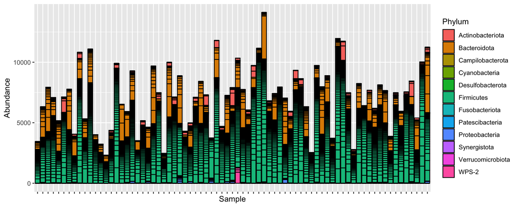

```r
# Absolute abundance
plot_bar(physeq, fill = "Phylum") + theme(axis.text.x = element_blank())
```

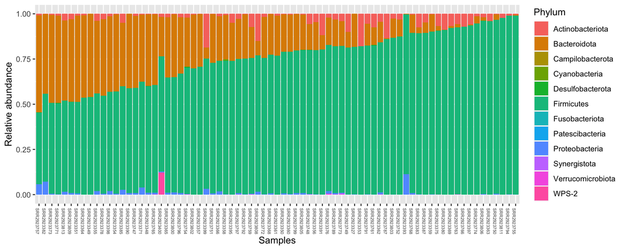

```r
# Relative abundance for Phylum
phylum.table <- physeq %>%
  tax_glom(taxrank = "Phylum") %>%                     # agglomerate at phylum level
  transform_sample_counts(function(x) {x/sum(x)} ) %>% # Transform to rel. abundance
  psmelt()                                             # Melt to long format

ggplot(phylum.table, aes(x = reorder(Sample, Sample, function(x) mean(phylum.table[Sample == x & Phylum == 'Firmicutes', 'Abundance'])),
                         y = Abundance, fill = Phylum))+
  geom_bar(stat = "identity") +
  theme(axis.text.x = element_text(size = 5, angle = -90))+
  labs(x = "Samples", y = "Relative abundance")
```